# Logarithmic Transformation

Mubarak Ganiyu

October 19, 2021

# 1 Introduction

Probability distributions have made it possible for people to develop a better understanding of the world as we apply them in different areas of life to test for the chances of random events occurring. Thereby, being able to measure the chances of success in different domains. There are many statistical distributions out there. However, this deliverable will be focusing only on three: gamma, lognormal and uniform.

# 2 Method

There are different functions that were used to generate the charts that were used in this deliverable. These functions can be seen in the code chunk below. The `pdf` function is used to plot the probability density function of the distrubutions. The `cdf` is used to plot the cumulative distribution function of the distributions. The `arith_vs_geom` is used to showcase the relationship between the arithmetic and geometric means of 1000 samples of data for each distribution. The final function, `hist_plot`, displays a side-by-side histogram distribution of both the arithmetic and geometric means for each distribution.

```r
pdf <- function(df, type, var) {
  ggplot(df) +
    geom_density(aes(x = type), fill = "grey") +
    geom_vline(aes(xintercept = mean(type)), color = "blue") +
    geom_vline(aes(xintercept = median(type)), color = "red") +
    labs(title = sprintf("Probability density function of %s",var),
         subtitle = "Blue represents mean, red represents median",
         x = "value") +
    theme_bw() +
    theme(plot.title = element_text(hjust=0.5),
          plot.subtitle = element_text(hjust=0.5))
}

cdf <- function(df, type, var) {
    ggplot(df, aes(type)) +
    stat_ecdf(geom = "step", color = "black") +
    geom_vline(aes(xintercept = mean(type)), color = "blue") +
    geom_vline(aes(xintercept = median(type)), color = "red") +
    labs(title = sprintf("Cumulative distribution function of %s", var),
         subtitle = "Blue represents mean, red represents median",
         x = "value",
         y = "percentile") +
    theme_bw() +
    theme(plot.title = element_text(hjust=0.5),
          plot.subtitle = element_text(hjust=0.5))
}

arith_vs_geom <- function(d, var, n1, n2) {
  x <- seq(n1, n2, by = ((n2 - n1)/(1000 - 1)))
  y <- seq(n1, n2, by = ((n2 - n1)/(1000 - 1)))
  df <- data.frame(x=x, y=y)
  ggplot(d) +
    geom_point(aes(y = arithmetic, x = geometric), color = "blue") +
    geom_line(aes(x=df$x,y=df$y),color = "red") +
    labs(title=sprintf("Arithmetic vs Geometric mean for %s", var),
         y = "Arithmetic mean",
         x = "Geometric mean") +
    theme_bw() +
    theme(plot.title = element_text(hjust=0.5),
          plot.subtitle = element_text(hjust=0.5))
}

hist_plot <- function(d, var, n) {
  ggplot(d) +
    geom_histogram(aes(x = abs(arithmetic-geometric)), binwidth=n,fill= "blue",alpha =0.4) +
    labs(x = "Difference between mean values",
         title= sprintf("Distribution of the difference between Arithmetic and Geometric mean values of %s", var)) +
    theme_bw() +
    theme(plot.title = element_text(hjust=0.5),
          plot.subtitle = element_text(hjust=0.5))
}
```

# 3 Questions and Answers

## 3.1 Part 1

For each distribution below, generate a figure of the PDF and CDF. Mark the mean and median in the figure.

For each distribution below, generate a figure of the PDF and CDF of the transformation Y = log(X) random variable. Mark the mean and median in the figure. You may use simulation or analytic methods in order find the PDF and CDF of the transformation.

For each of the distributions below, generate 1000 samples of size 100. For each sample, calculate the geometric and arithmetic mean. Generate a scatter plot of the geometic and arithmetic sample means. Add the line of identify as a reference line.

Generate a histogram of the difference between the arithmetic mean and the geometric mean.

*In all the graphs, a blue line represents the mean and a red line represents the median*

**Distribution 1**

X∼GAMMA(shape=3,scale=1)

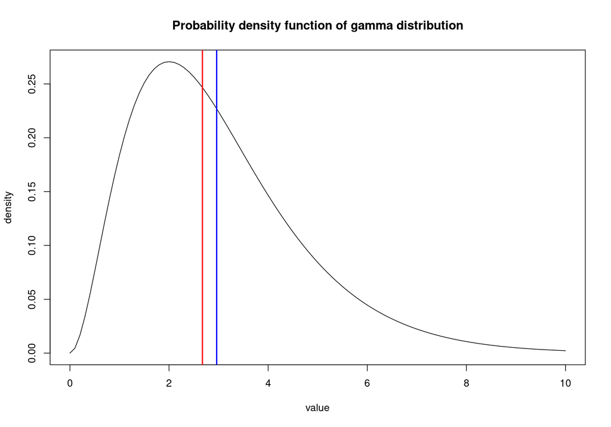

```r
mean <- mean(rgamma(1000, shape=3,scale=1))
curve(dgamma(x,shape=3,scale=1), xlim = c(0,10), main = "Probability density function of gamma distribution", xlab = "value", ylab = "density")
abline(v = mean, lwd = 2, col = "blue")
abline(v = qgamma(0.5,shape=3,scale=1), lwd = 2, col = "red")
```

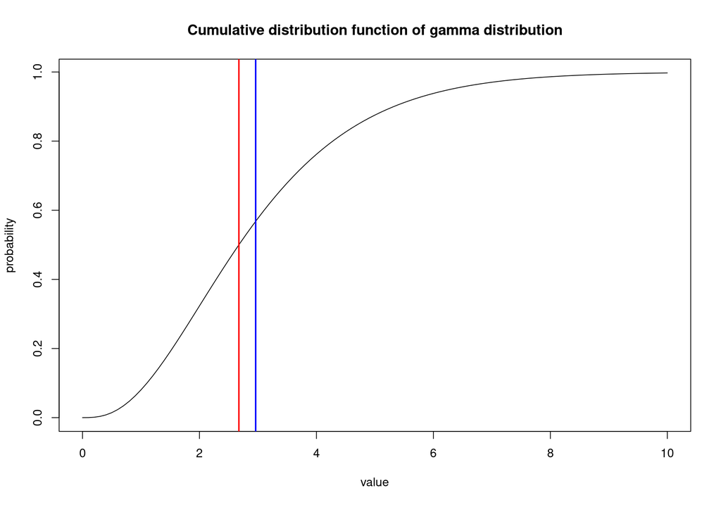

```r
curve(pgamma(x,shape=3,scale=1), xlim = c(0,10), main = "Cumulative distribution function of gamma distribution", xlab = "value", ylab = "probability")
abline(v = mean, lwd = 2, col = "blue")
abline(v = qgamma(0.5,shape=3,scale=1), lwd = 2, col = "red")
```

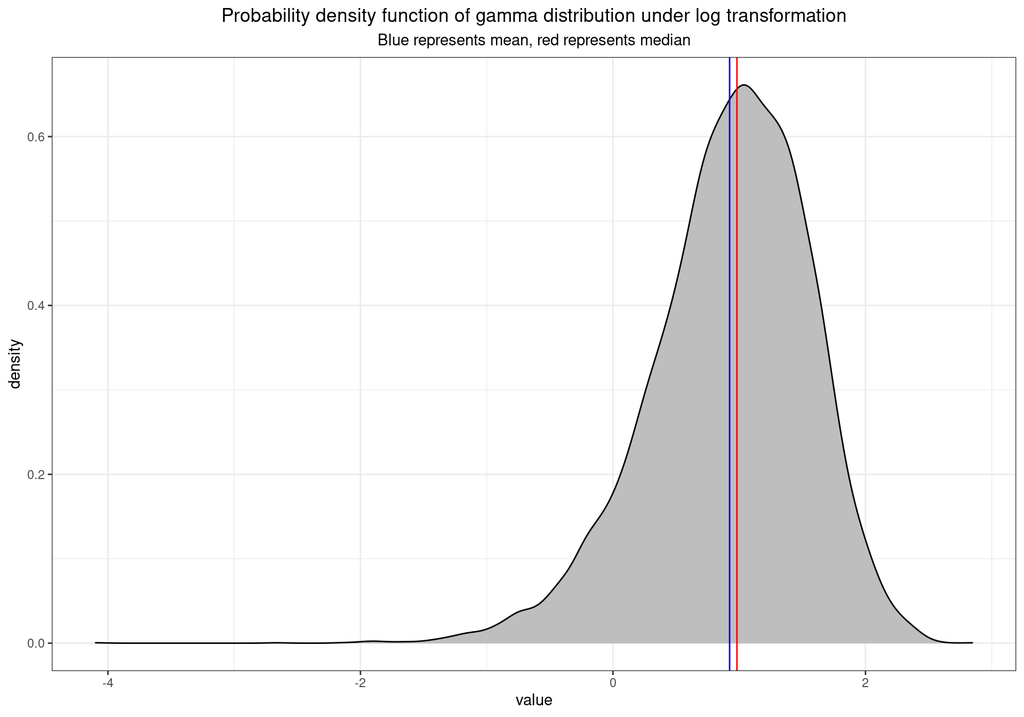

```r
gamma <- rgamma(10000, shape=3, scale=1)
x <- 1:10000
loggamma <- log(gamma)
df_gamma <- data.frame(x = x, gamma = gamma,loggamma = loggamma)
pdf(df_gamma, loggamma, "gamma distribution under log transformation")
```